# Introduction to linear models

3 April 2026

## Goals for today

- Identify whether a model is linear in the predictors
- Recognize that linear models can approximate nonlinear functions
- Understand the difference between categorical and continuous models
- Recognize the difference between written and coded factors

## Forms of linear models

| Errors | Single random process | Multiple random processes |
| --- | --- | --- |
| Normal | Linear Model (LM) | Linear Mixed Model (LMM) |
| Non-normal | Generalized Linear Model (GLM) | Generalized Linear Mixed Model (GLMM) |

## Forms of linear models

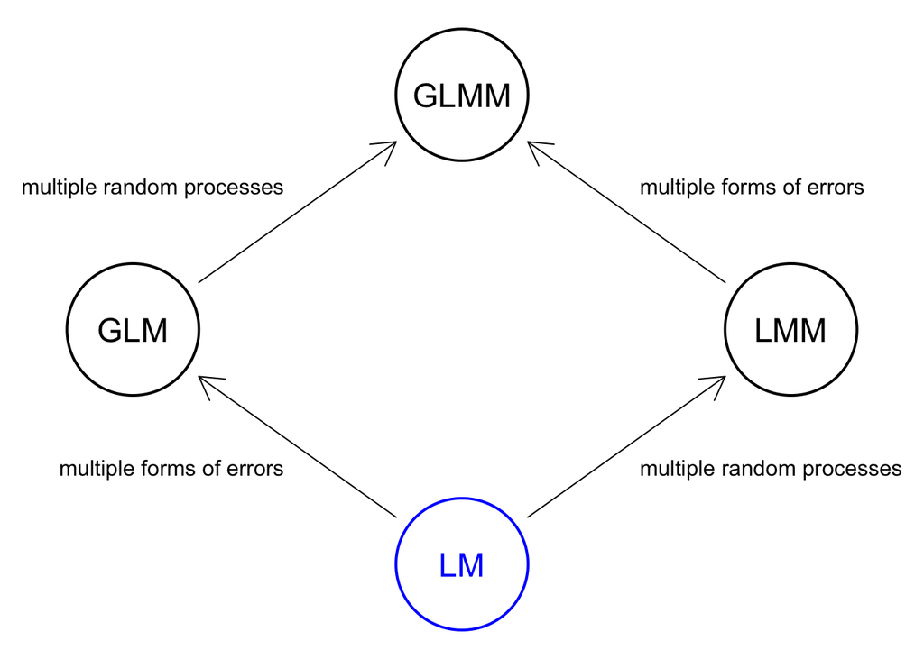

## What is a linear model?

A relationship that defines a response variable as a linear function of one or more predictor variables

## Which of these are linear models?

\(1) ~ y_i = \delta x_i\)

\(2) ~ y_i = \alpha + \beta x_i\)

\(3) ~ y_i = \alpha x_i^{\beta}\)

\(4) ~ y_i = \alpha + \beta x_i + \gamma z_i\)

\(5) ~ y_i = \alpha + \beta \frac{1}{x_i}\)

\(6) ~ y_t = \mu + \phi(y_{t-1} - \mu)\)

\(7) ~ y_i = (\alpha + x_i) \beta x_i\)

\(8) ~ y_i = \frac{\alpha x_i}{1 + \beta x_i}\)

## Which of these are linear models?

\(1) ~ y_i = \delta x_i\) ✔

\(2) ~ y_i = \alpha + \beta x_i\) ✔

\(3) ~ y_i = \alpha x_i^{\beta}\)

\(4) ~ y_i = \alpha + \beta x_i + \gamma z_i\) ✔

\(5) ~ y_i = \alpha + \beta \frac{1}{x_i}\)

\(6) ~ y_t = \mu + \phi(y_{t-1} - \mu)\) ✔

\(7) ~ y_i = (\alpha + x_i) \beta x_i\)

\(8) ~ y_i = \frac{\alpha x_i}{1 + \beta x_i}\)

## What is a linear model?

*A relationship that defines a response variable as a linear function of one or more predictor variables*

- characterized by a sum of terms, each of which is the product of a parameter and a single predictor

## Is this a linear model?

\[ y_i = \alpha (1 + \beta x_i) \]

## Is this a linear model?

\[ y_i = \alpha (1 + \beta x_i) \]

Yes, *if*

\[ \begin{align} y_i &= \alpha (1 + \beta x_i) \\ &= \alpha + \alpha \beta x_i \\ &= \alpha + \gamma x_i ~~ \text{with} ~~ \gamma = \alpha \beta \end{align} \]

## What is a linear model?

*A relationship that defines a response variable as a linear function of one or more predictor variables*

- characterized by a sum of terms, each of which is the product of a parameter and a single predictor
- the predictor can be a transformed variable

## Is this a linear model?

\[ y_i = \alpha + \beta x_i^2 \\ \]

## Linear transformations

Yes, if we allow for a transformation

\[ y_i = \alpha + \beta x_i^2 \\ \Downarrow \\ y_i = \alpha + \beta z_i \\ z_i = x_i^2 \]

## Linear vs nonlinear models

There are only 2 forms of a linear model with 2 parameters

\[ y_i = \alpha + \beta x_i \]

or

\[ y_i = \beta_1 x_{1,i} + \beta_2 x_{2,i} \]

## Linear vs nonlinear models

There are *many* forms of nonlinear models with 2 parameters

\[ y_i = \alpha x_i^{\beta} \\ y_i = \alpha + x_i^{\beta} \\ y_i = \alpha^{\beta x_i} \\ y_i = \alpha + \beta \frac{1}{x} \\ \vdots \]

## Linear vs nonlinear models

In linear models, effect sizes of different predictors are directly comparable

- intercept: units = response (eg, grams)
- slope: units = response per predictor (eg, grams per cm)

## Linear vs nonlinear models

In linear models, effect sizes of different predictors are directly comparable

- intercept: units = response (eg, grams)
- slope: units = response per predictor (eg, grams per cm)

In nonlinear models, common inference tools (*p*-values, confidence intervals) may not be available

## Locally linear models

If we reduce the interval of interest enough, we can approximate a nonlinear function with a linear model

\[ y = x^2 \\ \Downarrow \\ \frac{dy}{dx} = 2x \]

## Locally linear models

### Consider the quadratic \(y = \alpha + \beta x + x^2\)

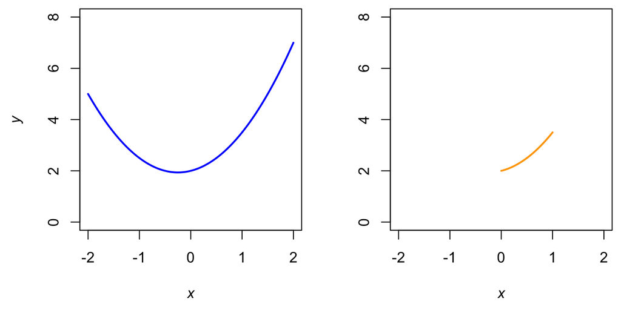

## Locally linear models

### A stochastic example with \(y = 2 + \tfrac{1}{2} x + x^2 + \epsilon_i\)

```r
set.seed(514)
nn <- 30
alpha <- 2
beta <- 1/2
eps <- rnorm(nn, 0, 1) ## errors ~ N(0,1)
x_all <- runif(nn, -2, 2)
y_all <- alpha + beta*x_all + x_all^2 + eps
x_loc <- x_all[x_all >= 0 & x_all <= 1]
y_loc <- y_all[x_all >= 0 & x_all <= 1]
```

## Locally linear models

### A stochastic example with \(y = 2 + \tfrac{1}{2} x + x^2 + \epsilon_i\)

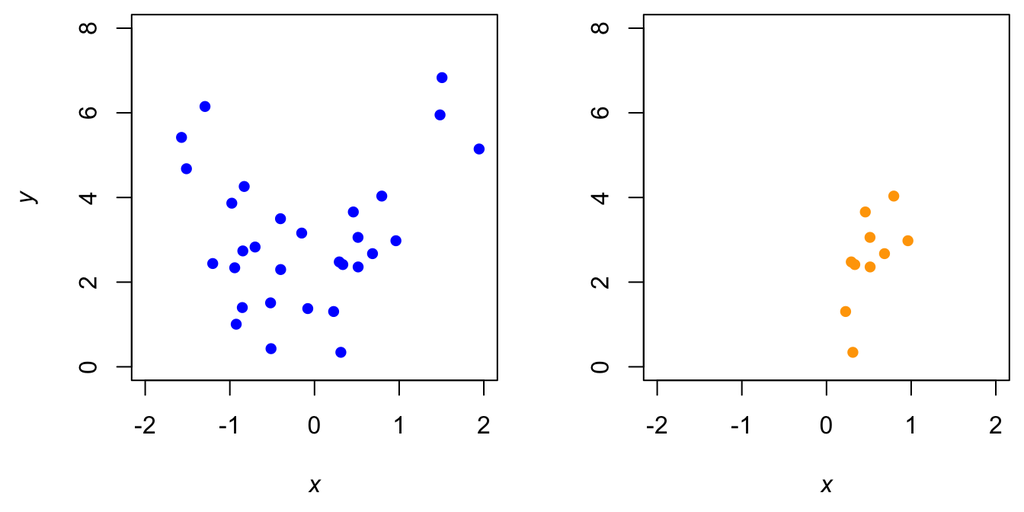

## Linear model for size of fish

In **R**, we can use `lm()` to fit linear regression models

\(y_i = \alpha + \beta x_i + e_i\)

`lm(y ~ x)`

(notice that the intercept \(\alpha\) is implicit here)

## Linear model for size of fish

In **R**, we use `summary()` to get info about a fitted model

`fitted_regr_model <- lm(L10_mass ~ L10_length)`

`summary(fitted_regr_model)`

## Locally linear models

```r
## model 1: full dataset
fit_1 <- lm(y_all ~ x_all)
summary(fit_1)
```

```
##
## Call:
## lm(formula = y_all ~ x_all)
##
## Residuals:
##     Min      1Q  Median      3Q     Max
## -2.8928 -0.9158 -0.2639  0.9593  3.4595
##
## Coefficients:
##             Estimate Std. Error t value Pr(>|t|)
## (Intercept)   3.1293     0.3075  10.176 6.54e-11 ***
## x_all         0.3395     0.3339   1.017    0.318
## ---
## Signif. codes:  0 '***' 0.001 '**' 0.01 '*' 0.05 '.' 0.1 ' ' 1
##
## Residual standard error: 1.669 on 28 degrees of freedom
## Multiple R-squared:  0.03559,    Adjusted R-squared:  0.001152
## F-statistic: 1.033 on 1 and 28 DF,  p-value: 0.3181
```

## Locally linear models

```r
## model 2: "local" data
fit_2 <- lm(y_loc ~ x_loc)
summary(fit_2)
```

```
##
## Call:
## lm(formula = y_loc ~ x_loc)
##
## Residuals:
##     Min      1Q  Median      3Q     Max
## -1.6465 -0.4216  0.0882  0.5340  1.2668
##
## Coefficients:
##             Estimate Std. Error t value Pr(>|t|)
## (Intercept)   1.1381     0.6993   1.627   0.1423
## x_loc         2.7334     1.2539   2.180   0.0609 .
## ---
## Signif. codes:  0 '***' 0.001 '**' 0.01 '*' 0.05 '.' 0.1 ' ' 1
##
## Residual standard error: 0.9015 on 8 degrees of freedom
## Multiple R-squared:  0.3727, Adjusted R-squared:  0.2942
## F-statistic: 4.752 on 1 and 8 DF,  p-value: 0.06087
```

## Linear model for size of fish

In **R**, we use `coef()` to extract the intercept(s) and slope(s)

`fitted_regr_model <- lm(y ~ x)`

`coef(fitted_regr_model)`

## Locally linear models

```r
## intercept and slope for model 2
coef(fit_2)
```

```
## (Intercept)       x_loc
##    1.138064    2.733440
```

## Locally linear models

```r
## intercept and slope for model 2
coef(fit_2)
```

```
## (Intercept)       x_loc
##    1.138064    2.733440
```

Estimate: \(\hat{y} \approx 1.1 + 2.7 x + 0 x^2\)

Linear models can be *good approximations* to nonlinear functions

## QUESTIONS?

Common forms for linear models

## A simple starting point

### Data = (Deterministic part) + (Stochastic part)

## Types of linear models

We classify linear models by the form of their deterministic part

Discrete predictor \(\rightarrow\) **AN**alysis **O**f **VA**riance (ANOVA)

Continuous predictor \(\rightarrow\) Regression

Both \(\rightarrow\) **AN**alysis of **COVA**riance (ANCOVA)

## Possible models for growth of fish

| Model | Description |
| --- | --- |
| \(\text{growth}_i = \alpha + \beta \text{species}_i + \epsilon_i\) | 1-way ANOVA |
| \(\text{growth}_i = \alpha + \beta_{1,\text{species}} + \beta_{2,\text{tank}} + \epsilon_i\) | 2-way ANOVA |
| \(\text{growth}_i = \alpha + \beta \text{ration}_i + \epsilon_i\) | simple linear regression |
| \(\text{growth}_i = \alpha + \beta_1 \text{ration}_i + \beta_2 \text{temperature}_i + \epsilon_i ~ ~\) | multiple regression |
| \(\text{growth}_i = \alpha + \beta_{1,\text{species}} + \beta_2 \text{ration}_i + \epsilon_i\) | ANCOVA |

## Fish growth data

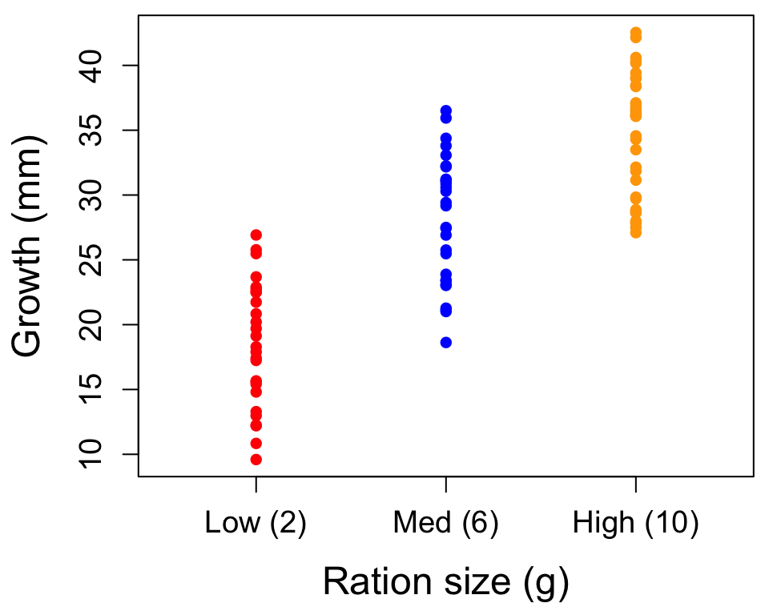

## ANOVA model

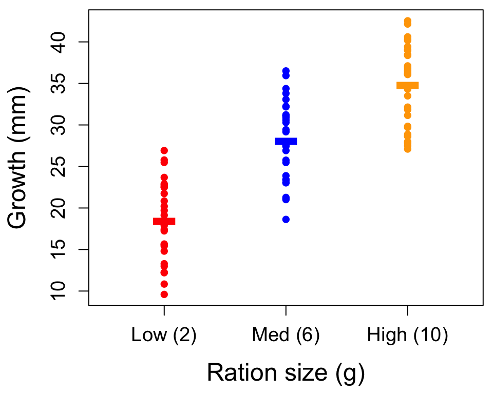

\(\text{growth}_i = \alpha + \beta_{\text{ration}} + \epsilon_i\)

## More info arrives

It turns out that targeting the exact ration is hard, but they know how much each fish ate during the trial

## Continuous predictor

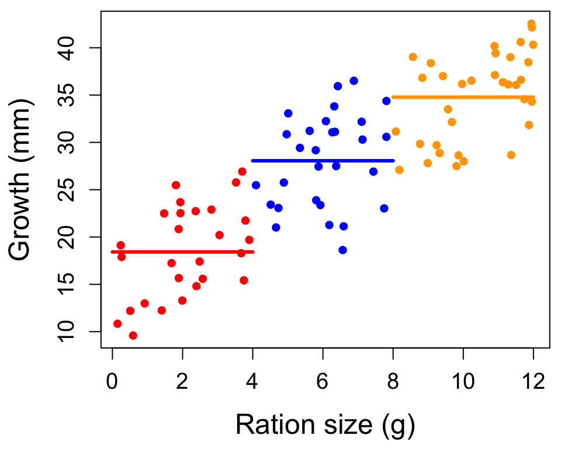

\(\text{growth}_i = \alpha + \beta_{\text{ration}} + \epsilon_i\)

## Continuous predictor

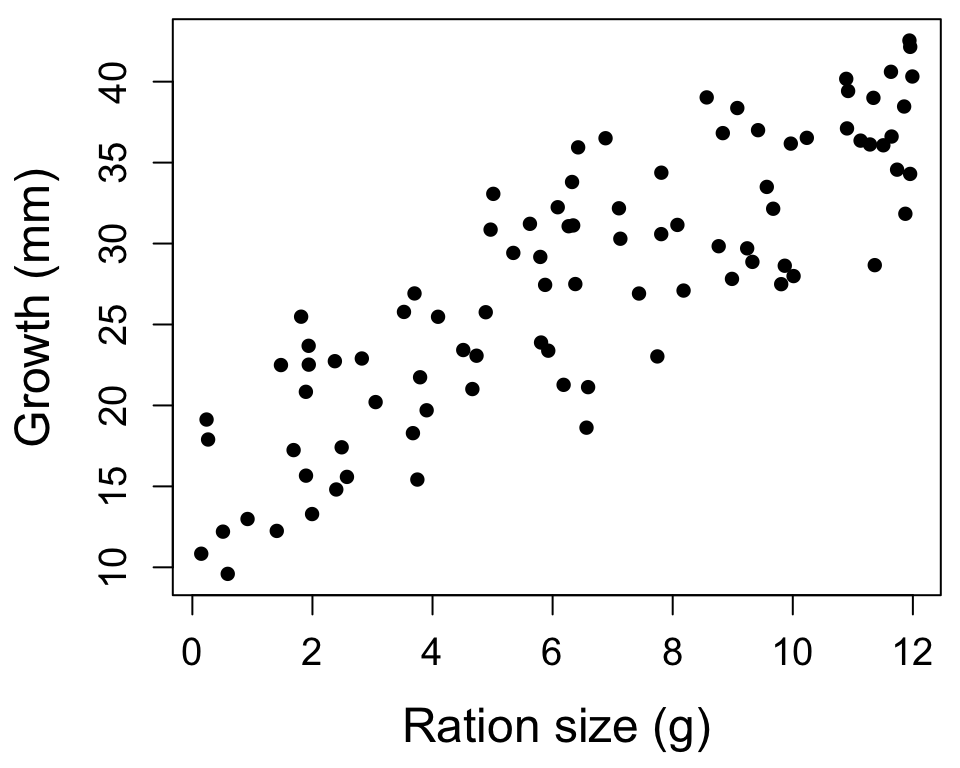

## Linear regression

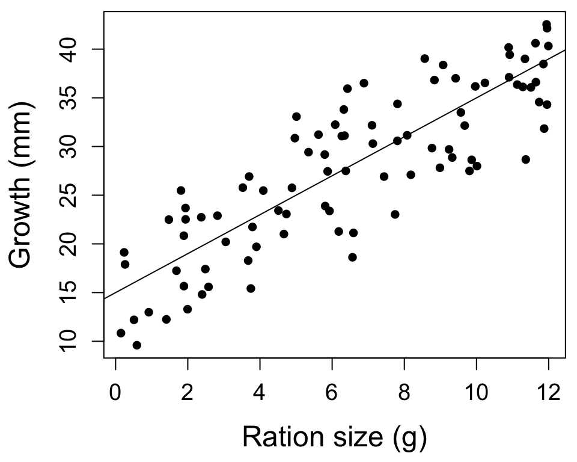

\(\text{growth}_i = \alpha + \beta \text{ration}_i + \epsilon_i\)

## More info arrives

It also turns out that there are 3 lineages of fish in the trials

## Continuous & discrete predictors

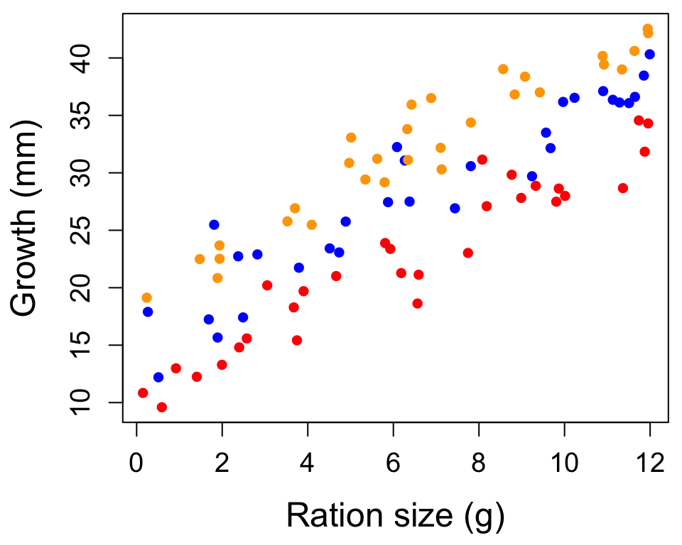

## ANCOVA

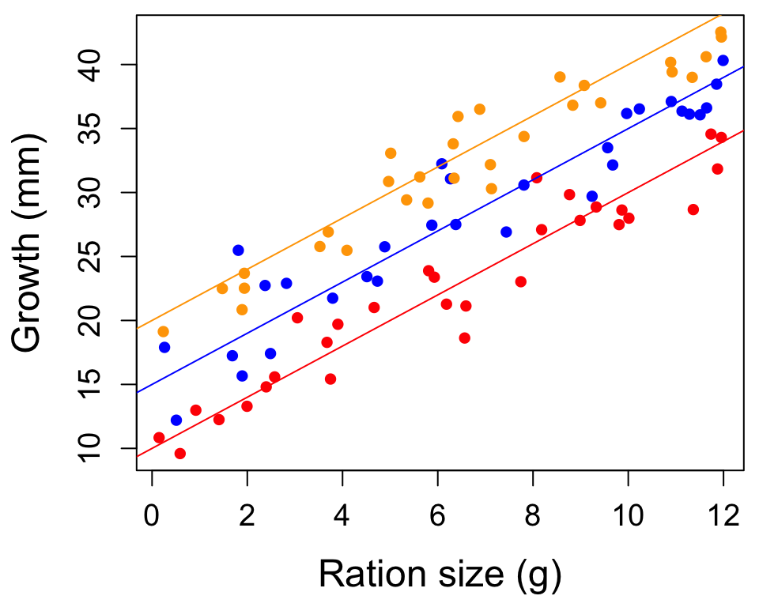

\(\text{growth}_i = \alpha + \beta_{1,\text{lineage}} + \beta_2 \text{ration}_i + \epsilon_i\)

## Notation for categorical effects

Here we have specified categorical effects in AN(C)OVA models as discrete parameters

For example, for a one-way ANOVA with 3 factors

\[ y_i = \alpha + \beta_j + \epsilon_i \]

the definition of \(\beta_j\) is

\[ \beta_j = \left\{ \begin{matrix} \beta_1 ~ \text{if factor 1} \\ \beta_2 ~ \text{if factor 2} \\ \beta_3 ~ \text{if factor 3} \end{matrix} \right. \]

## Notation for categorical effects

\[ y_i = \alpha + \beta_1 x_{1,i} + \beta_2 x_{2,i} + \beta_3 x_{3,i} + \epsilon_i \]

and each of the \(x_{j,i}\) indicates whether the \(i^{th}\) observation was assigned factor \(j\)

(We’ll visit this again when we discuss design matrices)